# Pipette Lab

Lauren Harris

# Pipette Lab

Date of Lab: 08/19/2020

## **Procedure**

1. A 100 microliter and 1000 microliter pipette were obtained
2. A beaker containing 10 mL of water was obtained and brought to a work station with a scale and weighing dish.
3. The scale was zeroed and the weighing dish was placed on the scale. The initial mass was recorded in the first row beneath “before”.
4. The pipette was set to 100 microliters (10% of the total volume) and a tip was placed on the end of the pipetter
5. Holding the pipette straight up and down, the plunger on the end of the pipette was depressed to the first stop and the tip was placed into the water.
6. Slowly relasing the plunger, water was drawn into the pipette tip and the pipette was removed from the water and transferred above the weighing dish
7. The plunger was depressed all the way to remove the water into the weighing dish. The final mass was recorded in the first row under “After” and also the next row under “Before”.
8. Increasing the pipette volume by 15%, steps 5-7 were repeated until 100% of the volume of the pipette (or 1000 microliters) was reached.
9. Using a 100 microliter pipette, the volume was set to 100 microliters and a tip was placed on the end of the pipette.
10. Steps 5-7 were repeated decreasing the volume of the pipette by 15% each time until 10% of the total volume (or 10 microliters) was reached.
11. The mass of water pipetted onto the wieghing dish was calculated by substracting the value in the “After” column with the corresponding value in the “Before” column.
12. The line of best fit was calculated for each pipette using the lm function
13. A plot of the mass of the water pipetted as a function of the volume set on the pipetter was created using different symbold for the different pipetters
14. The calculated best fit lines from each of the lm functions was added to the plot using a different line type for each plot.
15. A legend was added to the added to the plot and the results were analyzed.

## **Results**

### Data

Call: lm(formula = Mass ~ Volume, data = pipetteframe, subset = (Pipette == “1000D”))

Residuals: 1 2 3 4 5 6 7 -0.007143 0.007143 0.011429 -0.014286 0.010000 -0.015714 0.008571

Coefficients: Estimate Std. Error t value Pr(>|t|)  
(Intercept) 0.0000000 0.0103345 0.00 1  
Volume 0.0009714 0.0000165 58.89 2.67e-08 *** — Signif. codes: 0 ‘**’ 0.001 ’**’ 0.01 ’’ 0.05 ‘.’ 0.1 ’ ’ 1

Residual standard error: 0.01309 on 5 degrees of freedom Multiple R-squared: 0.9986, Adjusted R-squared: 0.9983 F-statistic: 3468 on 1 and 5 DF, p-value: 2.672e-08

#### Graph

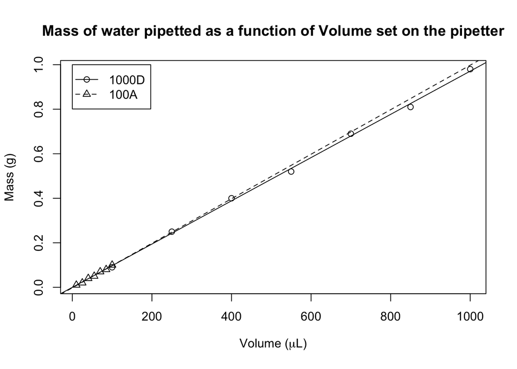

```r
plot(Mass ~ Volume, data=pipetteframe, type="n",
     main="Mass of water pipetted as a function of Volume set on the pipetter",
     xlab=expression(paste("Volume (", mu, "L)")),
     ylab="Mass (g)")
points(Mass ~ Volume, data=pipetteframe, pch=1, subset=(Pipette=="1000D"))
points(Mass ~ Volume, data=pipetteframe, pch=2, subset=(Pipette=="100A"))
abline(p1000lm, lty=1)
abline(p100lm, lty=2)
legend(0,1,legend=c("1000D","100A"),pch=1:2, lty=1:2)
```

```r
#Graph of the mass of water pippetted as a function of volume set on the pipetter
```